What makes a movie popular? The question is important for movie executives, online marketers, and social media companies, all who have a stake in promoting and partnering with the top movies of a season. In this project, I predict audience score based on a variety of variables about a random sample of movies from Rotten Tomatoes and IMDB.

## Part 1: Data

The data is a random sample of 651 movies released before 2016. With all requirements of randomization being justified, we can assume that this is representative of the population of movies that have Rotten Tomatoes and IMBD pages. This means that we can better make arguments about generalizability (only to this specific population of movies released before 2016, not after, through), and to association, but not causality. If we were interested in causality, we might want to amp up the methods and pursue something like matching, which could control for a variety of covariates in the model.

## Part 2: Data manipulation

First, I mutate, or create, new variables based on features that make more sense for the question at hand.

```r
library(tidyverse)

movies <- movies %>%
  mutate(feature_film = ifelse(title_type == "Feature Film", "yes", "no"),
         drama = ifelse(genre== "Drama", "yes", "no"),
         mpaa_rating_R = ifelse(mpaa_rating == "R", "yes", "no"),
         oscar_season = ifelse(thtr_rel_month %in% c(10, 11,12), "yes", "no"),
         summer_season = ifelse(thtr_rel_month %in% c(5,6,7,8), "yes", "no"))
```

## Part 3: Exploratory data analysis

The numerical variable of critics score is expectadely linearly associated, though not too strong, with audience score. The correlation between critics score and audience score is 0.70, which is moderate to strong, so we can certainly use this as a predictor. As for the collinearlity among features in the dat set, imdb_score is highly correlated with critics score, at 0.76, so we might not want to keep both of these variables in the set.

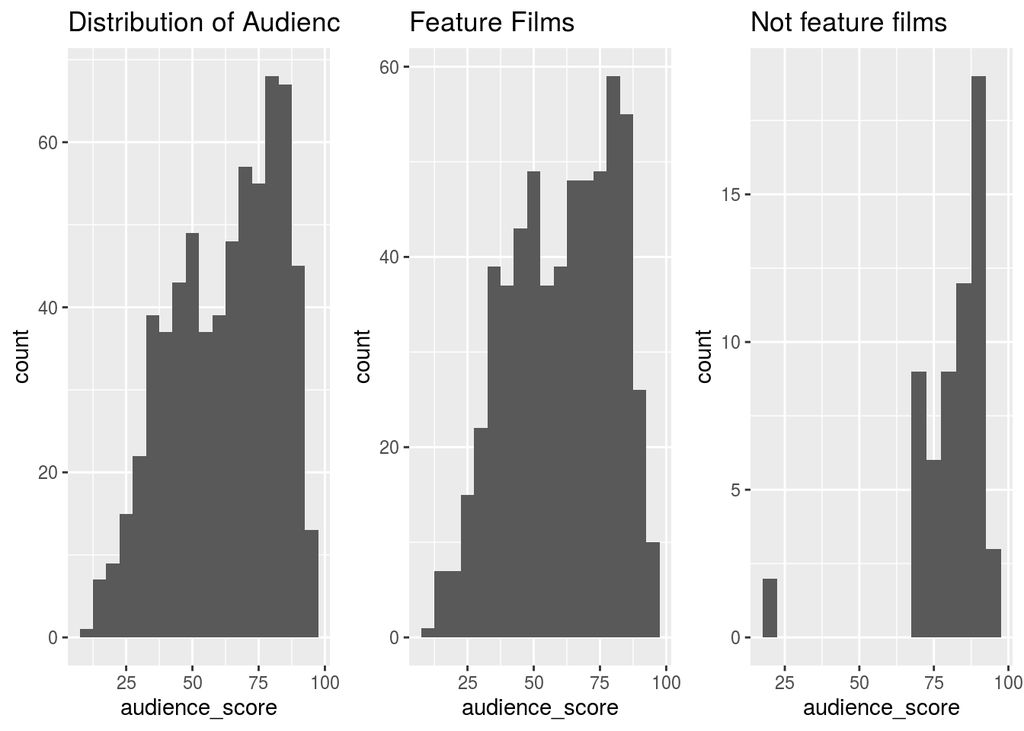

```r
# distribution of outcome

p1 <- ggplot(data = movies, aes(x = audience_score)) +
  geom_histogram(binwidth = 5) +
  ggtitle("Distribution of Audience Score for all Films")

#distribution of outcome for feature films
feature_films = filter(movies, feature_film == 'yes')
p2 <- ggplot(data = feature_films, aes(x = audience_score)) +
  geom_histogram(binwidth = 5) +
  ggtitle("Feature Films")
not_feature_films = filter(movies, feature_film == 'no')
p3 <- ggplot(data = not_feature_films, aes(x = audience_score)) +
  geom_histogram(binwidth = 5) +
  ggtitle("Not feature films")
grid.arrange(p1, p2, p3, nrow = 1)
```

```r
summary(feature_films$audience_score)
```

```
##    Min. 1st Qu.  Median    Mean 3rd Qu.    Max.
##   11.00   44.50   62.00   60.47   78.00   97.00
```

```r
summary(not_feature_films$audience_score)
```

```
##    Min. 1st Qu.  Median    Mean 3rd Qu.    Max.
##   19.00   76.50   85.50   81.05   89.00   96.00
```

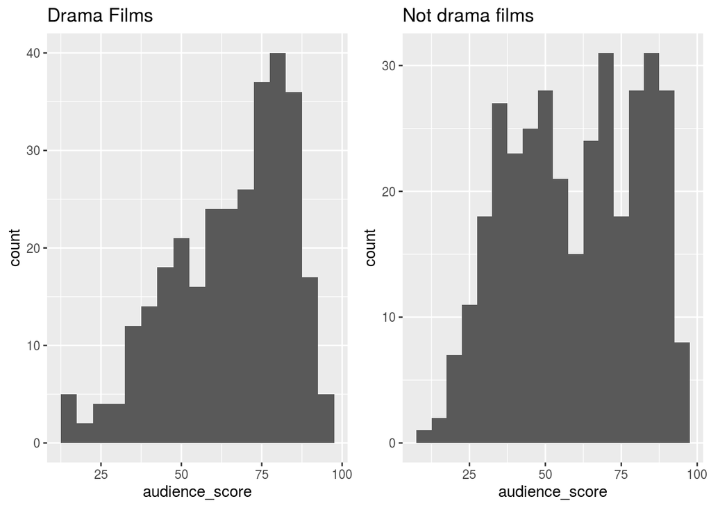

```r
#distribution of outcome for dramas
drama_films = filter(movies, drama == 'yes')
p1 <- ggplot(data = drama_films, aes(x = audience_score)) +
  geom_histogram(binwidth = 5) +
  ggtitle("Drama Films")
not_drama_films = filter(movies, drama == 'no')
p2 <- ggplot(data = not_drama_films, aes(x = audience_score)) +
  geom_histogram(binwidth = 5) +
  ggtitle("Not drama films")
grid.arrange(p1, p2, nrow = 1)
```

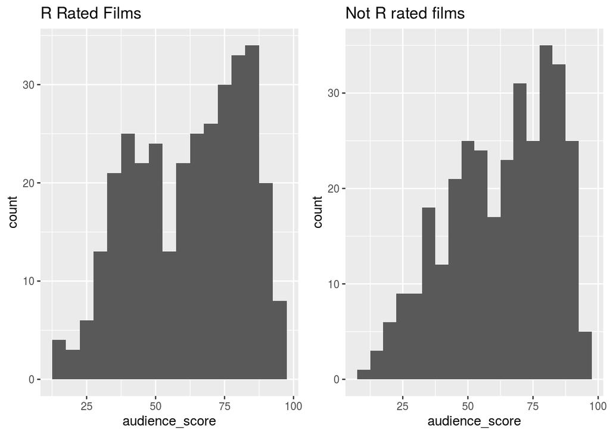

```r
#distribution of outcome for R rated films
R_rated_films = filter(movies, mpaa_rating_R== 'yes')
p1 <- ggplot(data = R_rated_films, aes(x = audience_score)) +
  geom_histogram(binwidth = 5) +
  ggtitle("R Rated Films")
not_R_rated_films = filter(movies, mpaa_rating_R == 'no')
p2 <- ggplot(data = not_R_rated_films, aes(x = audience_score)) +
  geom_histogram(binwidth = 5) +
  ggtitle("Not R rated films")
grid.arrange(p1, p2, nrow = 1)
```

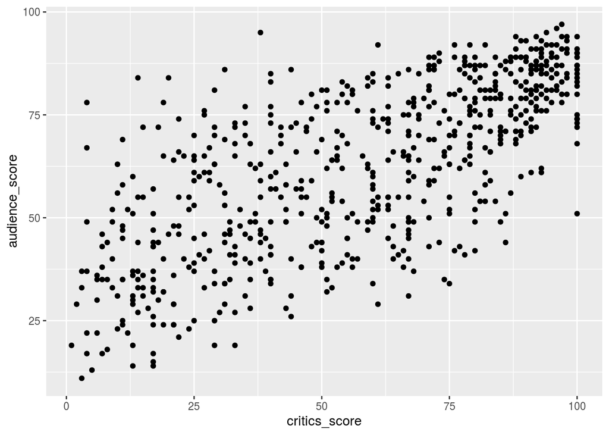

```r
ggplot(data = movies, aes(x = critics_score, y = audience_score)) +
  geom_point()
```

```r
cor(movies$audience_score, movies$critics_score)
```

```
## [1] 0.7042762
```

```r
numericals <- movies %>%
  dplyr::select(audience_score, runtime, thtr_rel_year,
         imdb_rating, imdb_num_votes, critics_score) %>%
  na.omit()
numericals$runtime <- as.numeric(numericals$runtime)
cor(numericals)
```

```
##                audience_score    runtime thtr_rel_year imdb_rating
## audience_score     1.00000000  0.1809629   -0.05479688  0.86490913
## runtime            0.18096290  1.0000000   -0.10437672  0.26824048
## thtr_rel_year     -0.05479688 -0.1043767    1.00000000 -0.03135507
## imdb_rating        0.86490913  0.2682405   -0.03135507  1.00000000
## imdb_num_votes     0.29029291  0.3472149    0.15675364  0.33216314
## critics_score      0.70415734  0.1724989   -0.08198620  0.76478324
##                imdb_num_votes critics_score
## audience_score      0.2902929     0.7041573
## runtime             0.3472149     0.1724989
## thtr_rel_year       0.1567536    -0.0819862
## imdb_rating         0.3321631     0.7647832
## imdb_num_votes      1.0000000     0.2100053
## critics_score       0.2100053     1.0000000
```

## Part 4: Modeling

From the full model, we want to take out oscar season and top 200 box_yes. This has the effect of reducing the BIC from 4934 to 4922. We can continue removing predictor variables until we find the lowest BIC, which in this case would be a BIC of 4872, in the most parsmionious model that has only two predictors, which are imbd_rating and critics_score. Then, using the step AIC, I evaluate the model with the lowest AIC value, which has a BIC of 4890, and includes the variables of critics_score and imbd_rating, but additionally has the variables of R rating and best_pic_no.

Using this model, I evaluate the marginal posterior inclusion probabilities for each variable. The probability of runtime is high at .48, and the others might not seem high, but are higher than the probability of such predictors without a model.As an additional note, model assumptions, such as normality, are met through the analysis.

```r
## develop a Bayesian regression model to predict audience score from the explanatory variables
## create a small data set
movies_small <- movies %>%
  dplyr::select(audience_score, feature_film, drama, runtime,
         mpaa_rating_R, thtr_rel_year, oscar_season, summer_season,
         imdb_rating, imdb_num_votes, critics_score, best_pic_nom,
         best_pic_win, best_actor_win, best_actress_win, best_dir_win,
         top200_box)
##full model
mod_full <- lm(audience_score ~ . - audience_score, data = movies_small)
summary(mod_full)
```

```
##
## Call:
## lm(formula = audience_score ~ . - audience_score, data = movies_small)
##
## Residuals:
##     Min      1Q  Median      3Q     Max
## -28.594  -6.156   0.157   5.909  53.125
##
## Coefficients:
##                       Estimate Std. Error t value Pr(>|t|)
## (Intercept)          1.244e+02  7.749e+01   1.606  0.10886
## feature_filmyes     -2.248e+00  1.687e+00  -1.332  0.18323
## dramayes             1.292e+00  8.766e-01   1.474  0.14087
## runtime             -5.614e-02  2.415e-02  -2.324  0.02042 *
## mpaa_rating_Ryes    -1.444e+00  8.127e-01  -1.777  0.07598 .
## thtr_rel_year       -7.657e-02  3.835e-02  -1.997  0.04628 *
## oscar_seasonyes     -5.333e-01  9.967e-01  -0.535  0.59280
## summer_seasonyes     9.106e-01  9.493e-01   0.959  0.33778
## imdb_rating          1.472e+01  6.067e-01  24.258  < 2e-16 ***
## imdb_num_votes       7.234e-06  4.523e-06   1.600  0.11019
## critics_score        5.748e-02  2.217e-02   2.593  0.00973 **
## best_pic_nomyes      5.321e+00  2.628e+00   2.025  0.04330 *
## best_pic_winyes     -3.212e+00  4.610e+00  -0.697  0.48624
## best_actor_winyes   -1.544e+00  1.179e+00  -1.310  0.19068
## best_actress_winyes -2.198e+00  1.304e+00  -1.686  0.09229 .
## best_dir_winyes     -1.231e+00  1.728e+00  -0.713  0.47630
## top200_boxyes        8.478e-01  2.782e+00   0.305  0.76067
## ---
## Signif. codes:  0 '***' 0.001 '**' 0.01 '*' 0.05 '.' 0.1 ' ' 1
##
## Residual standard error: 9.975 on 633 degrees of freedom
##   (1 observation deleted due to missingness)
## Multiple R-squared:  0.763,  Adjusted R-squared:  0.757
## F-statistic: 127.3 on 16 and 633 DF,  p-value: < 2.2e-16
```

```r
## complete Bayesian model selection
BIC(mod_full)
```

```
## [1] 4934.145
```

```r
#reduced model 1
mod_reduced <- lm(audience_score ~ . - oscar_season - top200_box, data = movies_small)
summary(mod_reduced)
```

```
##
## Call:
## lm(formula = audience_score ~ . - oscar_season - top200_box,
##     data = movies_small)
##
## Residuals:
##     Min      1Q  Median      3Q     Max
## -28.629  -6.023   0.186   5.919  53.334
##
## Coefficients:
##                       Estimate Std. Error t value Pr(>|t|)
## (Intercept)          1.261e+02  7.690e+01   1.640  0.10159
## feature_filmyes     -2.277e+00  1.684e+00  -1.352  0.17673
## dramayes             1.307e+00  8.739e-01   1.496  0.13515
## runtime             -5.796e-02  2.382e-02  -2.433  0.01527 *
## mpaa_rating_Ryes    -1.469e+00  8.068e-01  -1.820  0.06919 .
## thtr_rel_year       -7.739e-02  3.805e-02  -2.034  0.04241 *
## summer_seasonyes     1.137e+00  8.523e-01   1.334  0.18261
## imdb_rating          1.471e+01  6.053e-01  24.299  < 2e-16 ***
## imdb_num_votes       7.601e-06  4.355e-06   1.746  0.08137 .
## critics_score        5.780e-02  2.210e-02   2.615  0.00912 **
## best_pic_nomyes      5.148e+00  2.608e+00   1.974  0.04879 *
## best_pic_winyes     -3.123e+00  4.600e+00  -0.679  0.49746
## best_actor_winyes   -1.559e+00  1.176e+00  -1.325  0.18551
## best_actress_winyes -2.191e+00  1.301e+00  -1.684  0.09272 .
## best_dir_winyes     -1.290e+00  1.723e+00  -0.749  0.45417
## ---
## Signif. codes:  0 '***' 0.001 '**' 0.01 '*' 0.05 '.' 0.1 ' ' 1
##
## Residual standard error: 9.963 on 635 degrees of freedom
##   (1 observation deleted due to missingness)
## Multiple R-squared:  0.7628, Adjusted R-squared:  0.7576
## F-statistic: 145.9 on 14 and 635 DF,  p-value: < 2.2e-16
```

```r
BIC(mod_reduced)
```

```
## [1] 4921.56
```

```r
#reduced model 2
mod_reduced2 <- lm(audience_score ~ . - oscar_season - top200_box
                  - best_dir_win - summer_season - imdb_num_votes, data = movies_small)
summary(mod_reduced2)
```

```
##
## Call:
## lm(formula = audience_score ~ . - oscar_season - top200_box -
##     best_dir_win - summer_season - imdb_num_votes, data = movies_small)
##
## Residuals:
##     Min      1Q  Median      3Q     Max
## -28.089  -6.420   0.210   5.561  53.111
##
## Coefficients:
##                     Estimate Std. Error t value Pr(>|t|)
## (Intercept)         81.64181   73.46837   1.111   0.2669
## feature_filmyes     -1.32595    1.60780  -0.825   0.4099
## dramayes             0.99183    0.86058   1.153   0.2495
## runtime             -0.05172    0.02298  -2.251   0.0247 *
## mpaa_rating_Ryes    -1.49611    0.80746  -1.853   0.0644 .
## thtr_rel_year       -0.05619    0.03655  -1.537   0.1247
## imdb_rating         14.91642    0.58469  25.512   <2e-16 ***
## critics_score        0.05977    0.02197   2.720   0.0067 **
## best_pic_nomyes      5.63083    2.57887   2.183   0.0294 *
## best_pic_winyes     -2.45019    4.34798  -0.564   0.5733
## best_actor_winyes   -1.76505    1.17413  -1.503   0.1333
## best_actress_winyes -2.15604    1.30342  -1.654   0.0986 .
## ---
## Signif. codes:  0 '***' 0.001 '**' 0.01 '*' 0.05 '.' 0.1 ' ' 1
##
## Residual standard error: 9.981 on 638 degrees of freedom
##   (1 observation deleted due to missingness)
## Multiple R-squared:  0.7608, Adjusted R-squared:  0.7567
## F-statistic: 184.5 on 11 and 638 DF,  p-value: < 2.2e-16
```

```r
BIC(mod_reduced2)
```

```
## [1] 4907.624
```

```r
#reduced model 3
mod_reduced3 <- lm(audience_score ~ . - oscar_season - top200_box
                  - best_dir_win - summer_season - imdb_num_votes
                  - best_actor_win - best_actress_win, data = movies_small)
summary(mod_reduced3)
```

```
##
## Call:
## lm(formula = audience_score ~ . - oscar_season - top200_box -
##     best_dir_win - summer_season - imdb_num_votes - best_actor_win -
##     best_actress_win, data = movies_small)
##
## Residuals:
##     Min      1Q  Median      3Q     Max
## -27.613  -6.370   0.194   5.597  53.300
##
## Coefficients:
##                  Estimate Std. Error t value Pr(>|t|)
## (Intercept)      79.64397   73.65072   1.081  0.27994
## feature_filmyes  -1.54381    1.60892  -0.960  0.33765
## dramayes          0.85113    0.85993   0.990  0.32266
## runtime          -0.06388    0.02237  -2.856  0.00443 **
## mpaa_rating_Ryes -1.41069    0.80873  -1.744  0.08158 .
## thtr_rel_year    -0.05469    0.03664  -1.493  0.13597
## imdb_rating      14.92839    0.58620  25.466  < 2e-16 ***
## critics_score     0.05925    0.02203   2.690  0.00734 **
## best_pic_nomyes   4.70535    2.55427   1.842  0.06592 .
## best_pic_winyes  -2.42024    4.34305  -0.557  0.57754
## ---
## Signif. codes:  0 '***' 0.001 '**' 0.01 '*' 0.05 '.' 0.1 ' ' 1
##
## Residual standard error: 10.01 on 640 degrees of freedom
##   (1 observation deleted due to missingness)
## Multiple R-squared:  0.7588, Adjusted R-squared:  0.7554
## F-statistic: 223.7 on 9 and 640 DF,  p-value: < 2.2e-16
```

```r
BIC(mod_reduced3)
```

```
## [1] 4900.109
```

```r
#reduced model 4
mod_reduced4 <- lm(audience_score ~ . - oscar_season - top200_box
                  - best_dir_win - summer_season - imdb_num_votes
                  - best_actor_win - best_actress_win - feature_film
                  - drama - runtime - best_pic_nom - best_pic_win - thtr_rel_year
                  -mpaa_rating_R
                  , data = movies_small)
summary(mod_reduced4)
```

```
##
## Call:
## lm(formula = audience_score ~ . - oscar_season - top200_box -
##     best_dir_win - summer_season - imdb_num_votes - best_actor_win -
##     best_actress_win - feature_film - drama - runtime - best_pic_nom -
##     best_pic_win - thtr_rel_year - mpaa_rating_R, data = movies_small)
##
## Residuals:
##     Min      1Q  Median      3Q     Max
## -26.673  -6.770   0.719   5.499  52.454
##
## Coefficients:
##                Estimate Std. Error t value Pr(>|t|)
## (Intercept)   -37.07462    2.86593 -12.936  < 2e-16 ***
## imdb_rating    14.66518    0.56626  25.898  < 2e-16 ***
## critics_score   0.07324    0.02162   3.387 0.000748 ***
## ---
## Signif. codes:  0 '***' 0.001 '**' 0.01 '*' 0.05 '.' 0.1 ' ' 1
##
## Residual standard error: 10.08 on 647 degrees of freedom
##   (1 observation deleted due to missingness)
## Multiple R-squared:  0.7525, Adjusted R-squared:  0.7517
## F-statistic: 983.3 on 2 and 647 DF,  p-value: < 2.2e-16
```

```r
BIC(mod_reduced4)
```

```
## [1] 4871.629
```

```r
## now through stepAIC
stepAIC(mod_full)
```

```
## Start:  AIC=3006.94
## audience_score ~ (feature_film + drama + runtime + mpaa_rating_R +
##     thtr_rel_year + oscar_season + summer_season + imdb_rating +
##     imdb_num_votes + critics_score + best_pic_nom + best_pic_win +
##     best_actor_win + best_actress_win + best_dir_win + top200_box) -
##     audience_score
##
##                    Df Sum of Sq    RSS    AIC
## - top200_box        1         9  62999 3005.0
## - oscar_season      1        28  63018 3005.2
## - best_pic_win      1        48  63038 3005.4
## - best_dir_win      1        51  63040 3005.5
## - summer_season     1        92  63081 3005.9
## - best_actor_win    1       171  63160 3006.7
## - feature_film      1       177  63166 3006.8
## <none>                           62990 3006.9
## - drama             1       216  63206 3007.2
## - imdb_num_votes    1       255  63244 3007.6
## - best_actress_win  1       283  63273 3007.9
## - mpaa_rating_R     1       314  63304 3008.2
## - thtr_rel_year     1       397  63386 3009.0
## - best_pic_nom      1       408  63398 3009.1
## - runtime           1       538  63527 3010.5
## - critics_score     1       669  63659 3011.8
## - imdb_rating       1     58556 121545 3432.2
##
## Step:  AIC=3005.04
## audience_score ~ feature_film + drama + runtime + mpaa_rating_R +
##     thtr_rel_year + oscar_season + summer_season + imdb_rating +
##     imdb_num_votes + critics_score + best_pic_nom + best_pic_win +
##     best_actor_win + best_actress_win + best_dir_win
##
##                    Df Sum of Sq    RSS    AIC
## - oscar_season      1        26  63025 3003.3
## - best_pic_win      1        49  63047 3003.5
## - best_dir_win      1        52  63051 3003.6
## - summer_season     1        94  63093 3004.0
## - best_actor_win    1       169  63168 3004.8
## - feature_film      1       176  63175 3004.8
## <none>                           62999 3005.0
```

[output cut: 128 more lines]

```
##
## Step:  AIC=2998.81
## audience_score ~ runtime + mpaa_rating_R + thtr_rel_year + imdb_rating +
##     critics_score + best_pic_nom + best_actor_win + best_actress_win
##
##                    Df Sum of Sq    RSS    AIC
## <none>                           63757 2998.8
## - thtr_rel_year     1       201  63958 2998.9
## - best_actor_win    1       219  63976 2999.0
## - best_actress_win  1       266  64023 2999.5
## - mpaa_rating_R     1       367  64124 3000.5
## - best_pic_nom      1       442  64199 3001.3
## - runtime           1       519  64276 3002.1
## - critics_score     1       879  64635 3005.7
## - imdb_rating       1     67356 131113 3465.4
```

```
##
## Call:
## lm(formula = audience_score ~ runtime + mpaa_rating_R + thtr_rel_year +
##     imdb_rating + critics_score + best_pic_nom + best_actor_win +
##     best_actress_win, data = movies_small)
##
## Coefficients:
##         (Intercept)              runtime     mpaa_rating_Ryes
##            70.10675             -0.05116             -1.50528
##       thtr_rel_year          imdb_rating        critics_score
##            -0.05123             15.00149              0.06410
##     best_pic_nomyes    best_actor_winyes  best_actress_winyes
##             4.88277             -1.73482             -2.11568
```

```r
## with the lowest AIC fit
aic_fit_model <- lm(audience_score ~ runtime + mpaa_rating_R + thtr_rel_year + imdb_rating +
    critics_score + best_pic_nom + best_actor_win + best_actress_win, data = movies_small)
summary(aic_fit_model)
```

```
##
## Call:
## lm(formula = audience_score ~ runtime + mpaa_rating_R + thtr_rel_year +
##     imdb_rating + critics_score + best_pic_nom + best_actor_win +
##     best_actress_win, data = movies_small)
##
## Residuals:
##     Min      1Q  Median      3Q     Max
## -27.613  -6.343   0.178   5.356  52.999
##
## Coefficients:
##                     Estimate Std. Error t value Pr(>|t|)
## (Intercept)         70.10675   72.17547   0.971  0.33175
## runtime             -0.05116    0.02239  -2.285  0.02265 *
## mpaa_rating_Ryes    -1.50528    0.78367  -1.921  0.05520 .
## thtr_rel_year       -0.05123    0.03605  -1.421  0.15587
## imdb_rating         15.00149    0.57647  26.023  < 2e-16 ***
## critics_score        0.06410    0.02157   2.972  0.00307 **
## best_pic_nomyes      4.88277    2.31590   2.108  0.03539 *
## best_actor_winyes   -1.73482    1.16824  -1.485  0.13804
## best_actress_winyes -2.11568    1.29452  -1.634  0.10268
## ---
## Signif. codes:  0 '***' 0.001 '**' 0.01 '*' 0.05 '.' 0.1 ' ' 1
##
## Residual standard error: 9.973 on 641 degrees of freedom
##   (1 observation deleted due to missingness)
## Multiple R-squared:  0.7601, Adjusted R-squared:  0.7571
## F-statistic: 253.8 on 8 and 641 DF,  p-value: < 2.2e-16
```

```r
BIC(aic_fit_model)
```

```
## [1] 4890.199
```

```r
##Bayesian model averaging: multiple models are averaged to obtain posteriors of coefficients and predictions from new data
# Fit the model using Bayesian linear regression, `bas.lm` function in the `BAS` package
bma_lwage <- bas.lm(audience_score ~ runtime + mpaa_rating_R + thtr_rel_year + imdb_rating +
    critics_score + best_pic_nom + best_actor_win + best_actress_win, data = movies_small,
                   prior = "BIC",
                   modelprior = uniform())
# Print out the marginal posterior inclusion probabilities for each variable
## so, the posterior probability of runtime is high, at 0.47, and crics_score, and best_pic_no
bma_lwage
```

```
##
## Call:
## bas.lm(formula = audience_score ~ runtime + mpaa_rating_R + thtr_rel_year +
##     imdb_rating + critics_score + best_pic_nom + best_actor_win +
##     best_actress_win, data = movies_small, prior = "BIC", modelprior = uniform())
##
##
##  Marginal Posterior Inclusion Probabilities:
##           Intercept              runtime     mpaa_rating_Ryes
##             1.00000              0.48270              0.20316
##       thtr_rel_year          imdb_rating        critics_score
##             0.08617              1.00000              0.89551
##     best_pic_nomyes    best_actor_winyes  best_actress_winyes
##             0.12759              0.14874              0.14191
```

```r
# Top 5 most probably models
summary(bma_lwage)
```

```
##                     P(B != 0 | Y)    model 1       model 2       model 3
## Intercept               1.0000000     1.0000     1.0000000     1.0000000
## runtime                 0.4827044     1.0000     0.0000000     0.0000000
## mpaa_rating_Ryes        0.2031587     0.0000     0.0000000     0.0000000
## thtr_rel_year           0.0861735     0.0000     0.0000000     0.0000000
## imdb_rating             1.0000000     1.0000     1.0000000     1.0000000
## critics_score           0.8955084     1.0000     1.0000000     1.0000000
## best_pic_nomyes         0.1275921     0.0000     0.0000000     0.0000000
## best_actor_winyes       0.1487434     0.0000     0.0000000     1.0000000
## best_actress_winyes     0.1419059     0.0000     0.0000000     0.0000000
## BF                             NA     1.0000     0.9968489     0.2543185
## PostProbs                      NA     0.2122     0.2116000     0.0540000
## R2                             NA     0.7549     0.7525000     0.7539000
## dim                            NA     4.0000     3.0000000     4.0000000
## logmarg                        NA -3615.2791 -3615.2822108 -3616.6482224
##                           model 4       model 5
## Intercept               1.0000000     1.0000000
## runtime                 0.0000000     1.0000000
## mpaa_rating_Ryes        1.0000000     1.0000000
## thtr_rel_year           0.0000000     0.0000000
## imdb_rating             1.0000000     1.0000000
## critics_score           1.0000000     1.0000000
## best_pic_nomyes         0.0000000     0.0000000
## best_actor_winyes       0.0000000     0.0000000
## best_actress_winyes     0.0000000     0.0000000
## BF                      0.2521327     0.2391994
## PostProbs               0.0535000     0.0508000
## R2                      0.7539000     0.7563000
## dim                     4.0000000     5.0000000
## logmarg             -3616.6568544 -3616.7095127
```

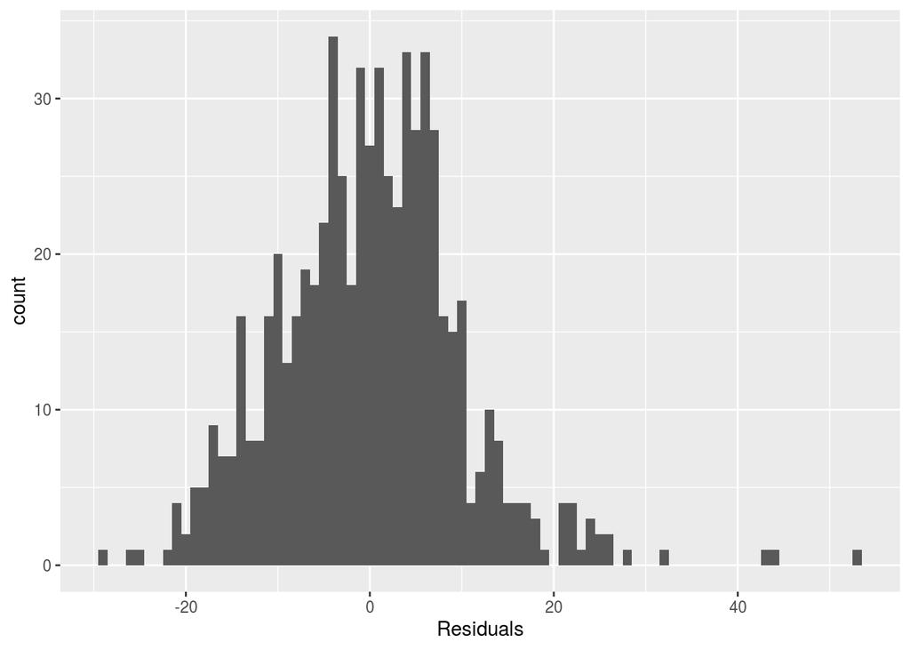

```r
##model diagnostics
library(MASS)
library(tidyverse)
library(statsr)
library(BAS)
library(broom)
mod_full_aug <- augment(mod_full)
ggplot(data = mod_full_aug, aes(x = .resid)) +
  geom_histogram(binwidth = 1) +
  xlab("Residuals")
```

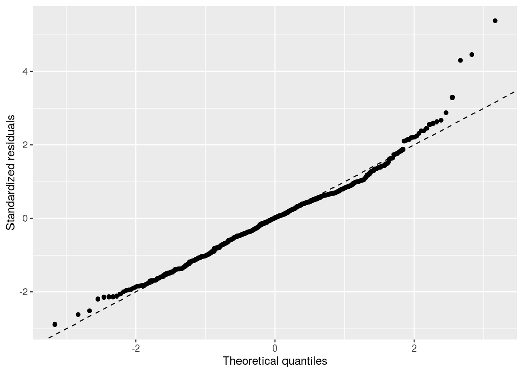

```r
ggplot(mod_full_aug) +
  geom_qq(aes(sample = .std.resid)) +
  geom_abline(slope = 1, intercept = 0, linetype = "dashed") +
  labs(x = "Theoretical quantiles", y = "Standardized residuals")
```

## Part 4.2: Interpretation of Final Model

In the final model, then a one point increase in imdb_rating is associated with a 15b point increase in audience score. Runtime is negatively associated, where longer movies have less audience score.

```r
## with the lowest AIC fit
aic_fit_model <- lm(audience_score ~ runtime + mpaa_rating_R + thtr_rel_year + imdb_rating +
    critics_score + best_pic_nom + best_actor_win + best_actress_win, data = movies_small)
summary(aic_fit_model)
```

```
##
## Call:
## lm(formula = audience_score ~ runtime + mpaa_rating_R + thtr_rel_year +
##     imdb_rating + critics_score + best_pic_nom + best_actor_win +
##     best_actress_win, data = movies_small)
##
## Residuals:
##     Min      1Q  Median      3Q     Max
## -27.613  -6.343   0.178   5.356  52.999
##
## Coefficients:
##                     Estimate Std. Error t value Pr(>|t|)
## (Intercept)         70.10675   72.17547   0.971  0.33175
## runtime             -0.05116    0.02239  -2.285  0.02265 *
## mpaa_rating_Ryes    -1.50528    0.78367  -1.921  0.05520 .
## thtr_rel_year       -0.05123    0.03605  -1.421  0.15587
## imdb_rating         15.00149    0.57647  26.023  < 2e-16 ***
## critics_score        0.06410    0.02157   2.972  0.00307 **
## best_pic_nomyes      4.88277    2.31590   2.108  0.03539 *
## best_actor_winyes   -1.73482    1.16824  -1.485  0.13804
## best_actress_winyes -2.11568    1.29452  -1.634  0.10268
## ---
## Signif. codes:  0 '***' 0.001 '**' 0.01 '*' 0.05 '.' 0.1 ' ' 1
##
## Residual standard error: 9.973 on 641 degrees of freedom
##   (1 observation deleted due to missingness)
## Multiple R-squared:  0.7601, Adjusted R-squared:  0.7571
## F-statistic: 253.8 on 8 and 641 DF,  p-value: < 2.2e-16
```

## Part 5: Prediction

Finally, I predict the score of movies in the dataset and evluate the difference in the predictions. Although I do not have access to other movies not in the dataset, what I would have done to answer this is scrape data from IMBD for a movie that is past the 2016 release date, and then predict it’s audience score using the variables of runtime, imbd_rating, etc., using the above regression model.

```r
movies.BMA <- predict(mod_full, estimator = "BPM", se.fit = TRUE)
fitted = movies.BMA$fit
as.vector(fitted)
```

[output not shown]

[output cut: 78 more lines]

## Part 6: Conclusion

What makes a good movie? Well, apparently it depends on what you define “good” to be. If we, as a company, are trying to optimize audience score, then different variables might be used in the prediction than if we were trying to optimize critics score, or probaiblity of recieving an oscar.

In this analysis, we focused on the former. That is, our intention is to build a prediction model that predicts audience score from a host of variables. While the most parsimonious model (with the lowest BIC), only included the two predictors of imbd_rating and critics_score, this might not be the best model, since it is leaving out variable information we have in other predictors. Additionally, imbd_rating and ceritics_score were highly correlated, as we saw from the initial descriptive statistics, and multi-collinearity might be resulting in a biased model.

Besides those statistical limitations of the analysis, shortcomings include a limited set of variables and the lack of a testing dataset to run predictions on. If I were to continue this research in the future, I’d again think about comparing the model to a different dependent, or outcome variable. What makes a movie “good” might be based on the box office monetary value, or the number of DVDs sold, rather than audience rating, which might be more subjective.